# Distance is the Soul of Beauty: How Open Border Policies Realign Ideology in Taiwan?

Jeffrey Kuo  
George Washington University  
Webpage: https://jeffjkuo.github.io  
Email: jeffkuo@gwu.edu  
Slides: https://rpubs.com/jeffkuo/NOV21TERP  
Taiwan Education and Research Program Initiative Meeting

Sunday, April 09, 2023

# About Me

- Academic
  - Ph.D. Candidate in Economics
  - Primary Fields: International Trade, Political Economy, Econometrics
  - Secondary Fields: International Finance, Taiwan Studies, Environmental Economics
  - Before GW:
    - [Syracuse University](https://syr.edu) (M.A. Economics at Maxwell School, ’16)
    - [Institute of Economics, Academia Sinica](http://www.econ.sinica.edu.tw/english) (Research Assistant, ’14)
    - R.O.C. Army (Army Officer, Second Lieutenant, ’13)
    - [National Chengchi University](https://www.nccu.edu.tw/app/home.php) (B.A + M.S. Honor Degree in International Trade, ’12)
  - Website: https://jeffjkuo.github.io ; Email: jeffkuo@gwu.edu
- Personal
  - From the City of Kaohsiung: Southern Pride!
  - Generation of Sunflower Movement…

# Overview of My Current Work

- “Distance is the Soul of the Beauty”
  - Question 1: “Do open border policies help the political integration?”
  - Question 2: “Does the heterogeneous exposure to Chinese visitors realign the ideology?”
  - Question 3: “Does China-Taiwan case violate the”progressive integration theory?”
- Preview of results
  - Answer 1: No
  - Answer 2: Yes (Visited by more Chinese tourists, the districts vote more to DPP)
  - Answer 3: Yes
- Contributions
  - New dataset: Election Results + GIS
  - RD models: Different local polynomial
  - Counter-example of B. Belassa’s Integration Theory

# Presidential Elections: Pre- v.s. Post- ECFA

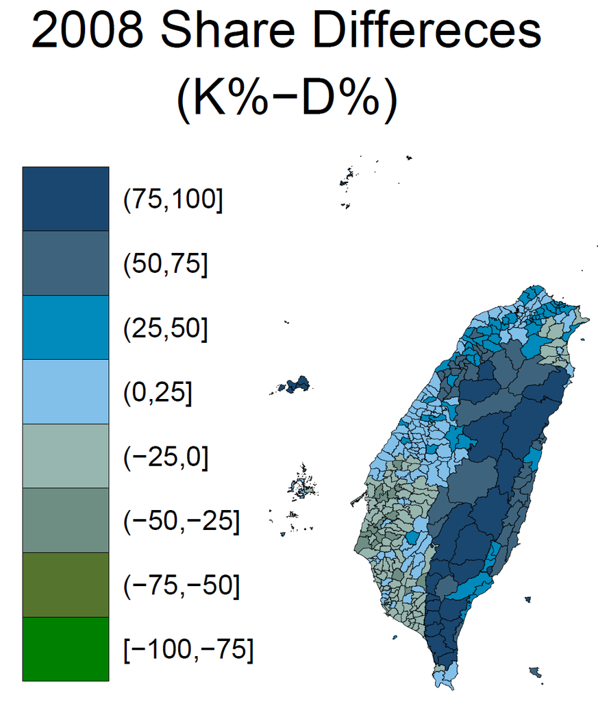

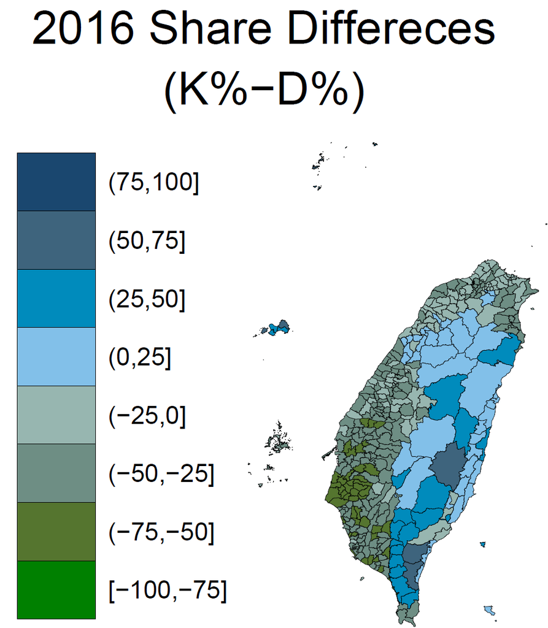

- Pattern? Which regions switch their party the most?

# Policy Shock

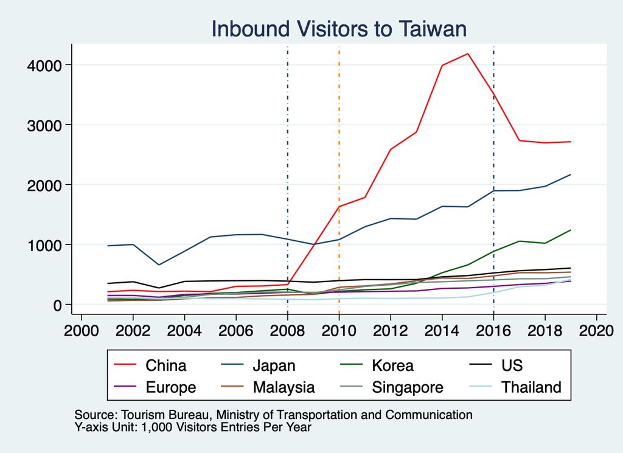

Inbound Visitors to Taiwan, 2001-2020

- ECFA
- Chinese Visitors to Taiwan

# Empirics

# RD Graphs

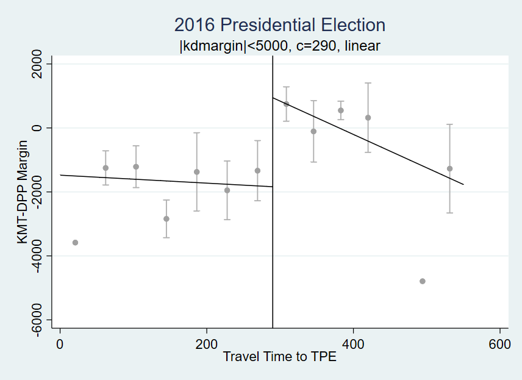

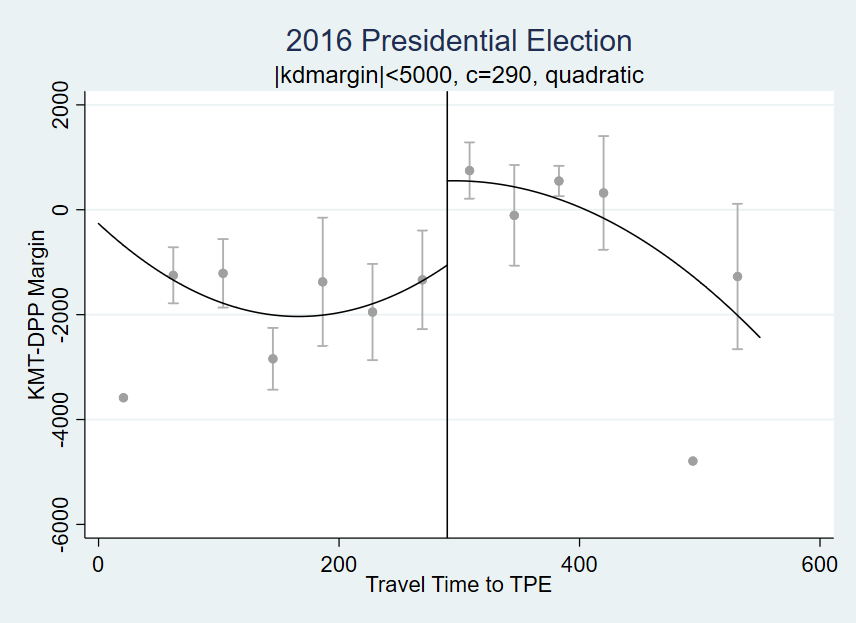

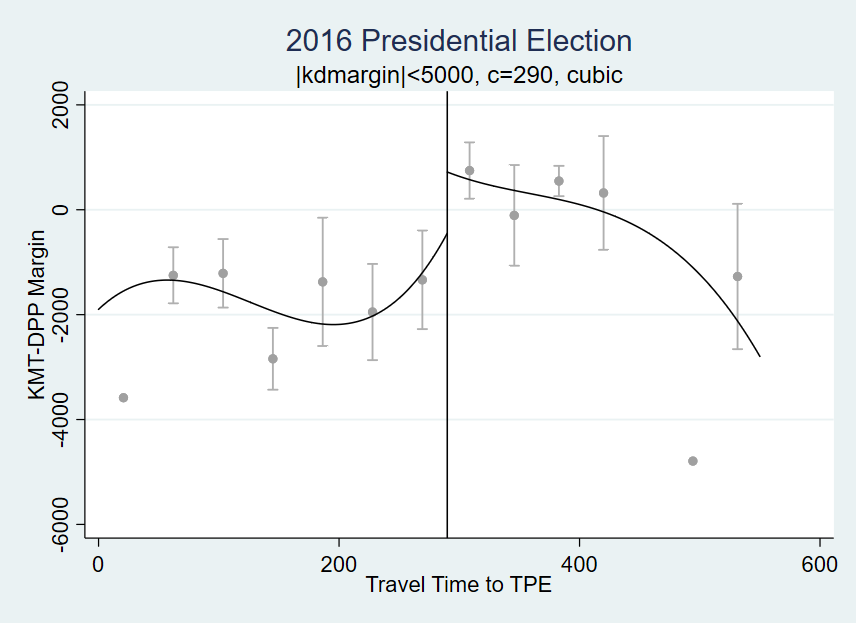

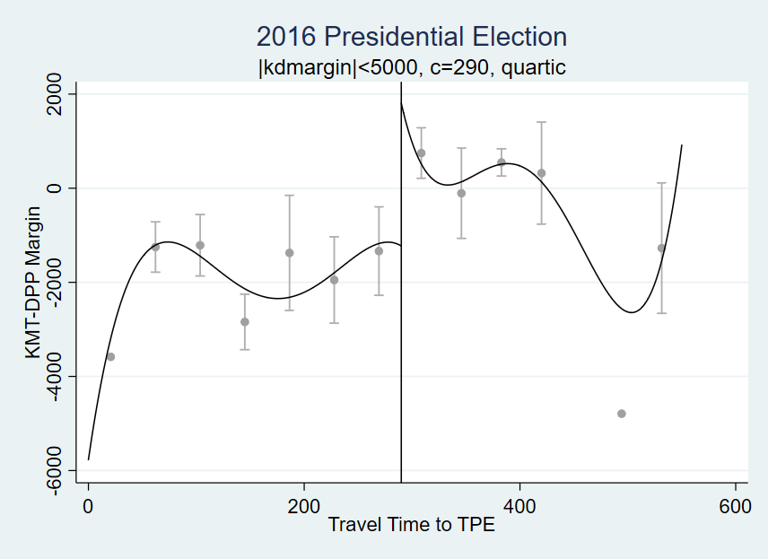

# End

- Future work
  - A modern trade theorectical model is needed
  - Explore the potential mechanism
- Thank YOU!
  - It’s really nice to see you (on zoom).
  - Please contact me anytime if you have question.
  - Look forward to have more academic interactions with you.